# DATA 612 Final Presentation: NYC Squirrels

Jithendra Sadu,

2022-12-13

## 1. Importing the data

First load necessary libraries for pre-processing, tidying, and visualization.

```r
library(tidyverse)
library(stringr)
library(dplyr)
library(car)
library(forcats)
library(scales)
library(tidyr)
```

```r
(nyc_squirrels <- read_csv("squirrel-data.csv", show_col_types = FALSE))
```

```
## # A tibble: 433 × 16
##    `Area Name` `Area ID` `Park Name` `Park ID` `Squirrel ID` `Primary Fur Color`
##    <chr>       <chr>     <chr>       <chr>     <chr>         <chr>
##  1 UPPER MANH… A         Fort Tryon… 01        A-01-01       Gray
##  2 UPPER MANH… A         Fort Tryon… 01        A-01-02       Gray
##  3 UPPER MANH… A         Fort Tryon… 01        A-01-03       Gray
##  4 UPPER MANH… A         Fort Tryon… 01        A-01-04       Gray
##  5 UPPER MANH… A         Fort Tryon… 01        A-01-05       Gray
##  6 UPPER MANH… A         Fort Tryon… 01        A-01-06       Gray
##  7 UPPER MANH… A         Fort Tryon… 01        A-01-07       Gray
##  8 UPPER MANH… A         Fort Tryon… 01        A-01-08       Black
##  9 UPPER MANH… A         Fort Tryon… 01        A-01-09       Gray
## 10 UPPER MANH… A         Fort Tryon… 01        A-01-10       Gray
## # ℹ 423 more rows
## # ℹ 10 more variables: `Highlights in Fur Color` <chr>, `Color Notes` <chr>,
## #   Location <chr>, `Above Ground (Height in Feet)` <chr>,
## #   `Specific Location` <chr>, Activities <chr>,
## #   `Interactions with Humans` <chr>, `Other Notes or Observations` <chr>,
## #   `Squirrel Latitude (DD.DDDDDD)` <dbl>,
## #   `Squirrel Longitude (-DD.DDDDDD)` <dbl>
```

```r
dim(nyc_squirrels)
```

```
## [1] 433  16
```

The NYC Squirrels data set has 433 observations/rows and 16 columns about each squirrel sighting in the New York City area. This data set is an analysis of squirrel sightings and their characteristics across New York City over the span of that day. The Squirrel Census is a multimedia science, design, and storytelling project focusing on the Eastern gray (Sciurus carolinensis). On March 1, 2020 — with the help of 72 volunteer Squirrel Sighters, as well as NYC Open Data — they performed a sample count in 24 New York City parks, and gathered other material data.

## 2. Presenting the data as a data frame and a tibble.

```r
class(nyc_squirrels)
```

```
## [1] "spec_tbl_df" "tbl_df"      "tbl"         "data.frame"
```

```r
is.data.frame(nyc_squirrels)
```

```
## [1] TRUE
```

The data set NYC squirrels is a data frame.

```r
is_tibble(nyc_squirrels)
```

```
## [1] TRUE
```

The data set NYC squirrels is a tibble.

```r
glimpse(nyc_squirrels)
```

```
## Rows: 433
## Columns: 16
## $ `Area Name`                       <chr> "UPPER MANHATTAN", "UPPER MANHATTAN"…
## $ `Area ID`                         <chr> "A", "A", "A", "A", "A", "A", "A", "…
## $ `Park Name`                       <chr> "Fort Tryon Park", "Fort Tryon Park"…
## $ `Park ID`                         <chr> "01", "01", "01", "01", "01", "01", …
## $ `Squirrel ID`                     <chr> "A-01-01", "A-01-02", "A-01-03", "A-…
## $ `Primary Fur Color`               <chr> "Gray", "Gray", "Gray", "Gray", "Gra…
## $ `Highlights in Fur Color`         <chr> "White", "White", "White", "White", …
## $ `Color Notes`                     <chr> NA, NA, NA, NA, NA, NA, NA, NA, NA, …
## $ Location                          <chr> "Ground Plane", "Ground Plane", "Gro…
## $ `Above Ground (Height in Feet)`   <chr> NA, NA, NA, NA, NA, NA, NA, "10", NA…
## $ `Specific Location`               <chr> NA, NA, NA, NA, NA, NA, NA, NA, NA, …
## $ Activities                        <chr> "Foraging", "Foraging", "Eating, Dig…
## $ `Interactions with Humans`        <chr> "Indifferent", "Indifferent", "Indif…
## $ `Other Notes or Observations`     <chr> NA, "Looks skinny", NA, NA, "She lef…
## $ `Squirrel Latitude (DD.DDDDDD)`   <dbl> 40.85941, 40.85944, 40.85942, 40.859…
## $ `Squirrel Longitude (-DD.DDDDDD)` <dbl> -73.93394, -73.93394, -73.93389, -73…
```

The columns have the structure as displayed above.

**Note:** For future cleaning, we would need to change the character data types of the categorical variables to factors.

## 3. Explaining the Data Set

The data set is a part of the Squirrel Census, a multimedia science, design, and storytelling project focusing on the Eastern gray (Sciurus carolinensis). On March 1, 2020 — with the help of 72 volunteer Squirrel Sighters, as well as NYC Open Data, they performed a sample count in 24 New York City parks, and gathered other material data and present their findings to the public.

The variables in our final data set, after tidying, are:

1. **Area Name**: The logistical area in which the park is located: Upper Manhattan, Central Manhattan, Lower Manhattan, or Brooklyn
2. **Park Name**: The specific park name where squirrels were counted.
3. **Primary Fur Color**: Value is either “Gray,” “Cinnamon” or “Black”.
4. **Location**: Value is either “Ground Plane”, “Above Ground”, or “Specific Location.” Squirrel Sighters were instructed to indicate the location where the squirrel was when first sighted.
5. **Above Ground**: For squirrels sighted above ground, Squirrel Sighters were asked to provide an estimate (in feet) for the squirrel’s height above ground when the squirrel was first sighted.
6. **Activities**: Value is one of the following: “Running,” “Chasing” (another squirrel), “Climbing” (a tree or other environmental landmark), “Eating,” or “Foraging” (for food). Squirrel Sighters were also given the option of writing in another value or adding notes. These notes are also included here.
7. **Interactions with Humans**: Value is one of the following: “Approaches” (a human, likely seeking food), “Indifferent” (to human presence), or “Runs From” (humans, likely seeing them as a threat). Squirrel Sighters were also given the option of writing in another value or adding notes. These notes are also included here.

## 4. Tidying the Data

```r
library(forcats)
levels(factor(nyc_squirrels$Location))
```

```
## [1] "Above Ground"                    "Above Ground, Specific Location"
## [3] "Ground Plane"                    "Ground Plane, Above Ground"
## [5] "Ground Plane, Specific Location" "Specific Location"
```

Since we won’t be using values other than Above Ground or Ground Plan we will change “Above Ground, Specific Location” to Above Ground and “Ground Plane, Above Ground”, “Ground Plane, Specific Location” to Ground Plane.

```r
nyc_squirrels[nyc_squirrels=="Above Ground, Specific Location"] <- "Above Ground"
nyc_squirrels[nyc_squirrels=="Ground Plane, Above Ground"]<- "Ground Plane"
nyc_squirrels[nyc_squirrels=="Ground Plane, Specific Location"] <- "Ground Plane"
nyc_squirrels[nyc_squirrels=="Ground Plane"] <- "Ground Plane"
levels(factor(nyc_squirrels$Location))
```

```
## [1] "Above Ground"      "Ground Plane"      "Specific Location"
```

We won’t remove Specific Location from the data set as we can filter it out with dplyr command when presenting visualizations. Now we’ll check Interactions with Humans.

```r
levels(factor(nyc_squirrels$`Interactions with Humans`))
```

```
##  [1] "Approaches"
##  [2] "Approaches, Runs From"
##  [3] "Approaches, watching us"
##  [4] "Cautious of"
##  [5] "Defensive"
##  [6] "Friendly"
##  [7] "Indifferent"
##  [8] "Indifferent, Preoccupied by HAAWK"
##  [9] "Indifferent, Runs From"
## [10] "Indifferent, Runs From (kids)"
## [11] "Indifferent, Staring"
## [12] "Interested in"
## [13] "Okay with people"
## [14] "Runs From"
## [15] "Runs From, watches us in short tree"
## [16] "Runs From, watchful"
## [17] "Skittish to humans"
## [18] "Staring"
## [19] "Watches us from tree"
## [20] "Watching"
## [21] "Watching us from tree - very interested in us"
```

As we can see there are several types of `Indifferents and Runs From`, let’s see if there several observations for each, if not we’ll collapse them into one.

```r
nyc_squirrels %>%
    select(`Interactions with Humans`) %>%
    group_by(`Interactions with Humans`) %>%
    count() %>%
    arrange(desc(n))
```

```
## # A tibble: 22 × 2
## # Groups:   Interactions with Humans [22]
##    `Interactions with Humans`            n
##    <chr>                             <int>
##  1 Indifferent                         251
##  2 <NA>                                 91
##  3 Approaches                           34
##  4 Runs From                            34
##  5 Indifferent, Preoccupied by HAAWK     6
##  6 Approaches, Runs From                 1
##  7 Approaches, watching us               1
##  8 Cautious of                           1
##  9 Defensive                             1
## 10 Friendly                              1
## # ℹ 12 more rows
```

Since many of them only have one observation we’ll collapse them to create better visualizations. We’ll keep Indifferent, Preoccupied by *HAAWK* since the distinction is important but edit the `HAAWK` to `Hawk`.

```r
nyc_squirrels <- nyc_squirrels %>%
    mutate(`Interactions with Humans`=recode(`Interactions with Humans`,"c('Indifferent, Runs From','Indifferent, Runs From (kids)','Indifferent, Staring') ='Indifferent'"))
nyc_squirrels <- nyc_squirrels %>%
    mutate(`Interactions with Humans`=recode(`Interactions with Humans`,"c('Approaches, Runs From','Friendly','Interested in','Okay with people') ='Approaches'"))
nyc_squirrels <- nyc_squirrels %>%
    mutate(`Interactions with Humans`=recode(`Interactions with Humans`,"c('Runs From, watches us in short tree','Runs From, watchful') ='Runs From'"))
nyc_squirrels <- nyc_squirrels %>%
    mutate(`Interactions with Humans`=recode(`Interactions with Humans`,"c('Cautious of','Skittish to humans','Watching us from tree - very interested in us','Watches us from tree','Watching') ='Unsure'"))
nyc_squirrels <- nyc_squirrels %>%
    mutate(`Interactions with Humans`=recode(`Interactions with Humans`,"'Indifferent, Preoccupied by HAAWK'='Indifferent, Preoccupied by Hawk'"))
```

Now lets check again the number of different values.

```r
levels(factor(nyc_squirrels$`Interactions with Humans`))
```

```
## [1] "Approaches"                       "Approaches, watching us"
## [3] "Defensive"                        "Indifferent"
## [5] "Indifferent, Preoccupied by Hawk" "Runs From"
## [7] "Staring"                          "Unsure"
```

```r
nlevels(factor(nyc_squirrels$`Interactions with Humans`))
```

```
## [1] 8
```

We have adequately summarized all Interactions with Humans into high level distinct categories. For Height Above Ground, one of our only quantitative variables, lets check its data type and see if there are any non-numeric values.

```r
class(nyc_squirrels$`Above Ground (Height in Feet)`)
```

```
## [1] "character"
```

```r
levels(factor(nyc_squirrels$`Above Ground (Height in Feet)`))
```

```
##  [1] "10\x89\xdb\xd212" "6\x89\xdb\xd218"  "2\x89\xdb\xd26"   "< 1"
##  [5] "1"                "10"               "20\x89\xdb\xd230" "12"
##  [9] "14"               "15"               "20\x89\xdb\xd240" "2"
## [13] "20"               "25"               "3"                "30"
## [17] "35"               "4"                "4...3...2...1"    "40"
## [21] "5"                "6"                "60"               "75"
## [25] "8"                "9"
```

So there’s some weird values for feet above ground as we can see, we’ll try to filter them out.

```r
# nyc_squirrels <- nyc_squirrels %>%
#     mutate(`Above Ground (Height in Feet)`=recode(`Above Ground (Height in Feet)`,"c('6\\x89\\xdb\\xd218','20\\x89\\xdb\\xd240','20\\x89\\xdb\\xd230','2\\x89\\xdb\\xd26','4...3...2...1','< 1') ='NA'"))
# nyc_squirrels <- nyc_squirrels %>%
#     filter(`Above Ground (Height in Feet)`!="NA")
```

We’re getting a multi-byte invalid string error any way we try to remove these values so we’ll identify the rows with these multi-byte invalid and filter them out.

Finally, we will check Activities since sighters were allowed to add another value along with main activities.

```r
levels(factor(nyc_squirrels$Activities))
```

```
##  [1] "battery"
##  [2] "Chasing"
##  [3] "Chasing, Climbing"
##  [4] "Chasing, Climbing, Eating"
##  [5] "Chattering"
##  [6] "Chillin', Rubbing butt on ground"
##  [7] "Chilling"
##  [8] "Cleaning"
##  [9] "Climbing"
## [10] "Climbing (down tree)"
## [11] "Climbing (down)"
## [12] "Climbing (tree)"
## [13] "Climbing fence"
## [14] "Climbing, Balancing on fencing"
## [15] "Climbing, Eating"
```

[output cut: 57 more lines]

From the output we can see that specific values/notes added to main activities are helpful by providing further context. However, we will collapse some where the distinction isn’t as helpful and there’s very low amount of observations.

```r
nyc_squirrels %>%
    select(Activities) %>%
    group_by(Activities) %>%
    count() %>%
    arrange(desc(n)) %>%
    print(n=70)
```

```
## # A tibble: 73 × 2
## # Groups:   Activities [73]
##    Activities                                 n
##    <chr>                                  <int>
##  1 Foraging                                  94
##  2 <NA>                                      55
##  3 Climbing                                  50
##  4 Running                                   36
##  5 Eating                                    34
##  6 Chasing                                   24
##  7 Eating, Foraging                          16
##  8 Climbing, Foraging                         7
##  9 Sitting                                    7
## 10 Chasing, Climbing                          6
## 11 Climbing (down)                            6
```

[output cut: 60 more lines]

After further review, because the subset values for the main activities have very low frequency counts we will collapse all similar values for Sitting, Running, Eating, Climbing, Chasing, Foraging.

```r
nyc_squirrels <- nyc_squirrels %>%
    mutate(Activities=recode(Activities,"c('Sitting (in tree hole)','Sitting on branch','Sitting
                                          at attention','Sitting, shouting','Sitting at attention') ='Sitting'"))
nyc_squirrels <- nyc_squirrels %>%
    mutate(Activities=recode(Activities,"c('Running, Eating','Running, Chasing, Climbing','Running, Foraging','Running, Eating','Running, up tree','Running, Climbing, Foraging','Running, Eating, Foraging','Running, Digging','Running, Eating (peanuts)','Running, Chasing, Eating','Running, Climbing, Eating','Running, Climbing, Scratching','Running, Chasing','Running, Climbing','Running, Eating (or pretending to eat)') ='Running'"))
nyc_squirrels <- nyc_squirrels %>%
    mutate(Activities=recode(Activities,"c('Eating, Digging something','Eating, Digging','Eating, Foraging','Ear scratching','Eating, Burying','Eating (nuts), Foraging','Eating (bread crumbs), Foraging','Eating (tortilla/chip)','Snacking in a tree')='Eating'"))
nyc_squirrels <- nyc_squirrels %>%
    mutate(Activities=recode(Activities,"c('Climbing, Foraging','Climbing, Eating','Climbing (down tree)','Climbing (down)','Climbing, Watching #2','Climbing, Eating, Foraging','Climbing, Balancing on fencing','Climbing (tree)','Climbing fence','Climbing, Foraging, Self-cleaning','Climbing, Sitting in short tree','') ='Climbing'"))
nyc_squirrels <- nyc_squirrels %>%
    mutate(Activities=recode(Activities,"c('Chasing, Climbing','Chasing, Climbing, Eating','Chasing, Climbing, Eating') ='Chasing'"))
nyc_squirrels <- nyc_squirrels %>%
    mutate(Activities=recode(Activities,"c('Foraging, Jumping','Foraging, Nesting/gathering leaves') ='Foraging'"))
levels(factor(nyc_squirrels$Activities))
```

```
##  [1] "battery"                          "Chasing"
##  [3] "Chattering"                       "Chillin', Rubbing butt on ground"
##  [5] "Chilling"                         "Cleaning"
##  [7] "Climbing"                         "Defending tree, shouting"
##  [9] "Digging"                          "Eating"
## [11] "Foraging"                         "Frolicking"
## [13] "Grooming"                         "Guarding"
## [15] "Hangin' with #13 & #14"           "Hanging"
## [17] "Hanging out"                      "Jumped to building"
## [19] "Lounging"                         "Nesting"
## [21] "Posing"                           "Prancing about"
## [23] "Resting in tree"                  "Running"
## [25] "Sitting"                          "Sleeping"
## [27] "Sleeping (Dead?)"                 "Sticking out of a tree"
## [29] "Very carefully watching a cat"    "Vocalization at us"
```

We can also see that there’s several variations of Chilling, such as lounging, hanging, hanging out, etc. We will collapse these into value, Chilling, as well. Same for movement.

```r
nyc_squirrels <- nyc_squirrels %>%
    mutate(Activities = str_replace(Activities, "Chilling","Chillin', Rubbing butt on ground"))
nyc_squirrels <- nyc_squirrels %>%
    mutate(Activities = str_replace(Activities, "Chilling","Hangin' with #13 & #14"))

nyc_squirrels <- nyc_squirrels %>%
    mutate(Activities=recode(Activities,"c('Chillin, Rubbing butt on ground','Hangin with #13 & #14','Hanging','Hanging out','Lounging','Posing','Resting in tree','Sitting') ='Chilling'"))
nyc_squirrels <- nyc_squirrels %>%
    mutate(Activities=recode(Activities,"c('Sleeping (Dead?)') ='Sleeping'"))
nyc_squirrels <- nyc_squirrels %>%
    mutate(Activities=recode(Activities,"c('Prancing about','Running') ='Frolicking'"))
levels(factor(nyc_squirrels$Activities))
```

```
##  [1] "battery"                          "Chasing"
##  [3] "Chattering"                       "Chillin', Rubbing butt on ground"
##  [5] "Chilling"                         "Cleaning"
##  [7] "Climbing"                         "Defending tree, shouting"
##  [9] "Digging"                          "Eating"
## [11] "Foraging"                         "Frolicking"
## [13] "Grooming"                         "Guarding"
## [15] "Hangin' with #13 & #14"           "Jumped to building"
## [17] "Nesting"                          "Sleeping"
## [19] "Sticking out of a tree"           "Very carefully watching a cat"
## [21] "Vocalization at us"
```

```r
nlevels(factor(nyc_squirrels$Activities))
```

```
## [1] 21
```

We have significantly reduced the amount of different types of activities from 73 to 21. And as we can see the ones remaining provide key summarization of squirrel behavior in NYC Parks. From here we will ignore Activities that have less than 1 observation.

```r
nyc_squirrels <- nyc_squirrels %>%
    filter(n() > 1)

nlevels(factor(nyc_squirrels$Activities))
```

```
## [1] 21
```

```r
sum(is.na(nyc_squirrels))
```

```
## [1] 1813
```

```r
colSums(is.na(nyc_squirrels))
```

```
##                       Area Name                         Area ID
##                               0                               0
##                       Park Name                         Park ID
##                               0                               0
##                     Squirrel ID               Primary Fur Color
##                               0                               1
##         Highlights in Fur Color                     Color Notes
##                              94                             423
##                        Location   Above Ground (Height in Feet)
##                              34                             321
##               Specific Location                      Activities
##                             344                              55
##        Interactions with Humans     Other Notes or Observations
##                              91                             266
##   Squirrel Latitude (DD.DDDDDD) Squirrel Longitude (-DD.DDDDDD)
##                              92                              92
```

```r
nyc_squirrels[complete.cases(nyc_squirrels), ]
```

```
## # A tibble: 0 × 16
## # ℹ 16 variables: Area Name <chr>, Area ID <chr>, Park Name <chr>,
## #   Park ID <chr>, Squirrel ID <chr>, Primary Fur Color <chr>,
## #   Highlights in Fur Color <chr>, Color Notes <chr>, Location <chr>,
## #   Above Ground (Height in Feet) <chr>, Specific Location <chr>,
## #   Activities <chr>, Interactions with Humans <chr>,
## #   Other Notes or Observations <chr>, Squirrel Latitude (DD.DDDDDD) <dbl>,
## #   Squirrel Longitude (-DD.DDDDDD) <dbl>
```

As we can see Color Notes, Specific Location, and Above Ground (Height in Feet), and Other Notes or Observations have the highest amount of NAs. We’ll control for those NA’s when we’re using those variables for visualization but will not drop those rows from the dataframe as they contain valuable information for other variables related to squirrel sightings and no single row is without a NA value.

## 5. Data Visualizations

First we’ll start wider and look at squirrels sightings by general area across New York City.

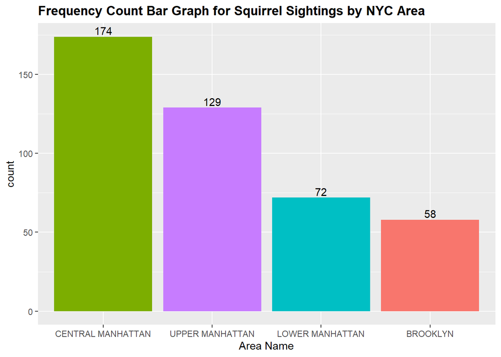

```r
nyc_squirrels %>%
  ggplot(aes(x = fct_infreq(`Area Name`))) +
  geom_bar(aes(fill=`Area Name`),show.legend = FALSE) +
  labs(x = "Area Name") +
    geom_text(aes(label = after_stat(count)), stat = "count", vjust=-.25, position = position_dodge(width=0.9)) +
    ggtitle("Frequency Count Bar Graph for Squirrel Sightings by NYC Area") +
    theme(plot.title = element_text(face = "bold"))
```

Central Manhattan had the highest amount of observations, followed by Upper Manhattan. Now we’ll look more closely at number of squirrels sightings by NYC Park during the time period.

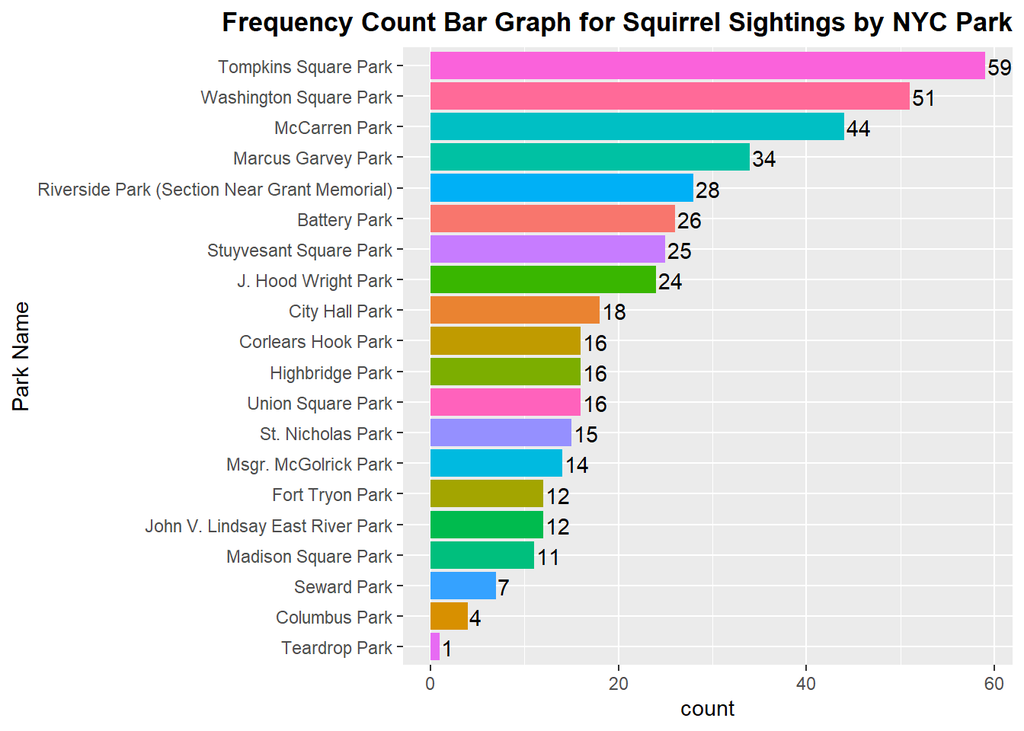

```r
nyc_squirrels %>%
  ggplot(aes(x = fct_rev(fct_infreq(`Park Name`)))) +
  geom_bar(aes(fill=`Park Name`),show.legend = FALSE) +
  labs(x="Park Name") +
    geom_text(aes(label=after_stat(count)),stat="count",vjust=.55, hjust=-.1, position =position_dodge(width=0.9)) +
    coord_flip() +
    ggtitle("Frequency Count Bar Graph for Squirrel Sightings by NYC Park") +
    theme(plot.title = element_text(hjust = 1, face="bold"))
```

Tompkins Square Park has the highest observed frequency count of all Parks. Let’s look at Tompkins Square Park grouped by activity.

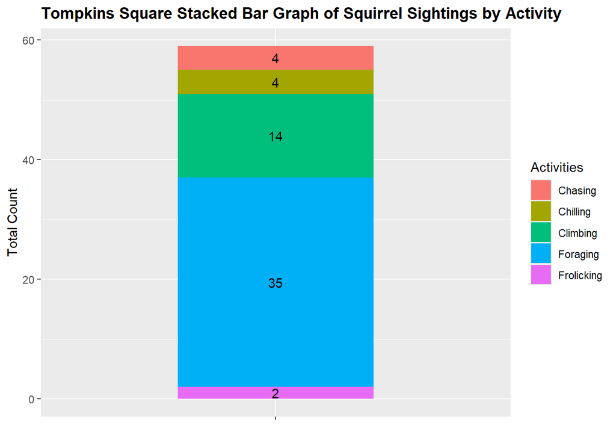

```r
nyc_squirrels %>%
    filter(`Park Name`=="Tompkins Square Park") %>%
    select(Activities) %>%
    drop_na() %>%
    group_by(Activities) %>%
    count(sort=TRUE) %>%
    rename(`Total Count`=n) %>%
    ggplot(aes(x="",y=`Total Count`,fill=Activities)) +
    geom_bar(width=.5,stat="identity",) +
    geom_text(aes(label=`Total Count`),position=position_stack(.5)) +
    theme(plot.title = element_text(face = "bold")) +
    labs(title="Tompkins Square Stacked Bar Graph of Squirrel Sightings by Activity",x=NULL)
```

As we can see, the majority of squirrels were either Foraging or Climbing. Let’s now see regardless of Park, the proportion of each Activity for squirrels across NYC Parks. We will ignore NA values.

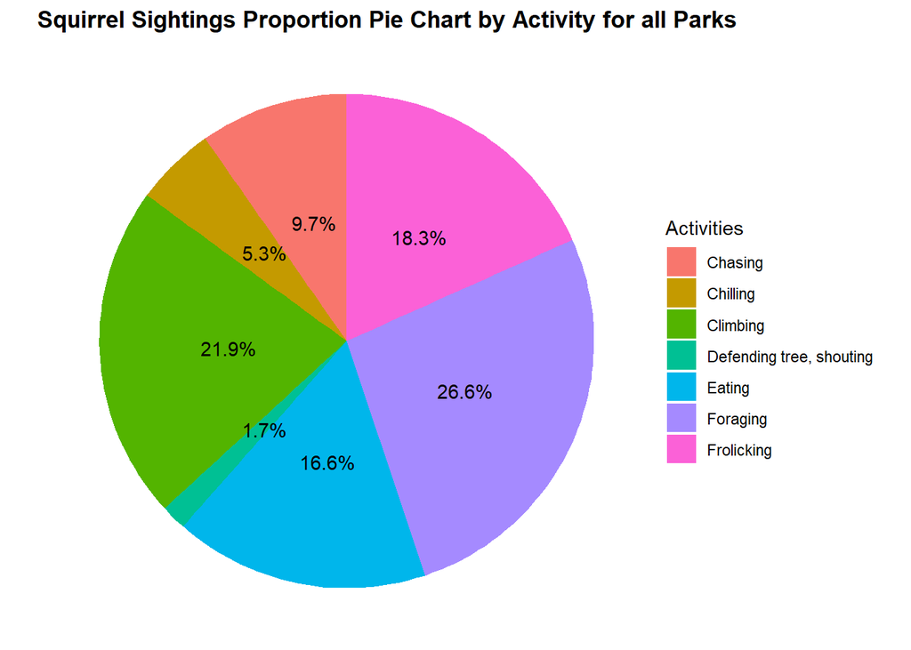

```r
nyc_squirrels %>%
    select(Activities) %>%
    drop_na() %>%
    group_by(Activities) %>%
    filter(n() > 5) %>%
    count() %>%
    ungroup() %>%
    mutate(perc = `n` / sum(`n`)) %>%
    arrange(perc) %>%
    mutate(labels = scales::percent(perc)) %>%
    ggplot(aes(x ="",y=perc,fill=Activities)) +
    geom_col() +
    coord_polar(theta = "y") +
    ggtitle("Squirrel Sightings Proportion Pie Chart by Activity for all Parks") +
    geom_text(aes(label = labels), position = position_stack(vjust = .5),hjust=.4) +
    theme_void() +
    theme(plot.title = element_text(face = "bold"))
```

As we can see, Foraging and Climbing remain popular activities regardless of Park. Eating was also a popular activity across all Parks. Now lets look at all Activities by count rather than proportion.

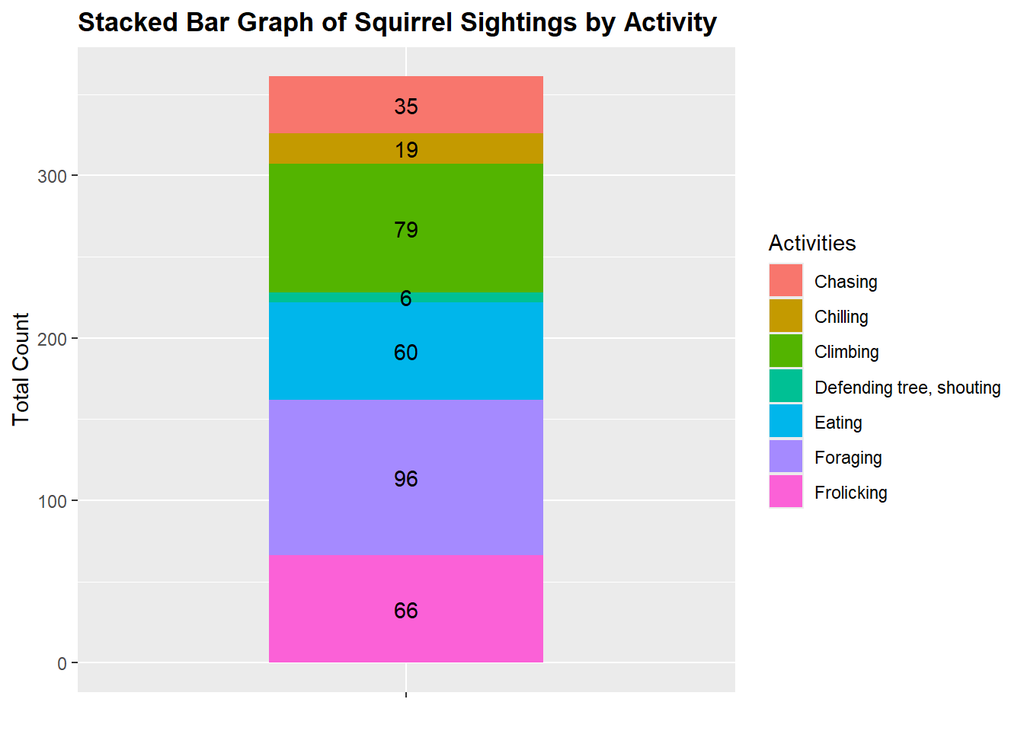

```r
nyc_squirrels %>%
    select(Activities) %>%
    drop_na() %>%
    group_by(Activities) %>%
    count(sort=TRUE) %>%
    rename(`Total Count`=n) %>%
    filter(`Total Count` > 5) %>%
    ggplot(aes(x="",y=`Total Count`,fill=Activities)) +
    geom_bar(width=.5,stat="identity",) +
    geom_text(aes(label=`Total Count`),position=position_stack(.5)) +
    labs(title="Stacked Bar Graph of Squirrel Sightings by Activity",x=NULL) +
    theme(plot.title = element_text(face = "bold"))
```

As we can see, Eating, Frolicking, Climbing, Foraging were the most popular Activities each with frequency count equal to or greater than 60.

Now lets look at squirrels sightings proportionally by Primary Fur Color.

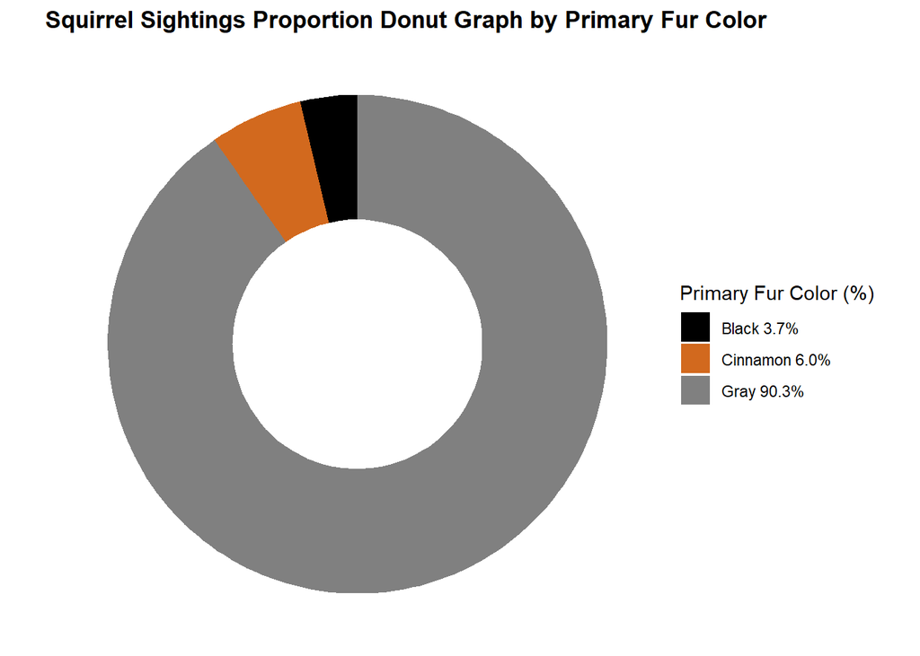

```r
custom_colors <- c("#000000", "#D2691E", "#808080")
nyc_squirrels %>%
    select(`Primary Fur Color`) %>%
    drop_na() %>%
    group_by(`Primary Fur Color`) %>%
    count() %>%
    ungroup() %>%
    mutate(perc = `n` / sum(`n`) * 100) %>%
    arrange(desc(perc)) %>%
    mutate(`Primary Fur Color (%)` = paste(`Primary Fur Color`, scales::percent(perc / 100), sep = " "),
           ylabel_position = ((cumsum(perc) - 0.5 * perc)),
           ymax = cumsum(perc),
           ymin = c(0, head(ymax, n=-1))) %>%
    ggplot(aes(ymax=ymax, ymin=ymin, xmax=4, xmin=3, fill=`Primary Fur Color (%)`)) +
    geom_rect() +
    coord_polar(theta="y", start = 0) +
    xlim(c(2, 4)) +
    labs(title = "Squirrel Sightings Proportion Donut Graph by Primary Fur Color") +
    scale_fill_manual(values = custom_colors) +
    theme_void() +
    theme(plot.title = element_text(face = "bold"))
```

As we can see, the majority of squirrel sightings had a primary fur color of gray. Now lets look at the total count for each fur color.

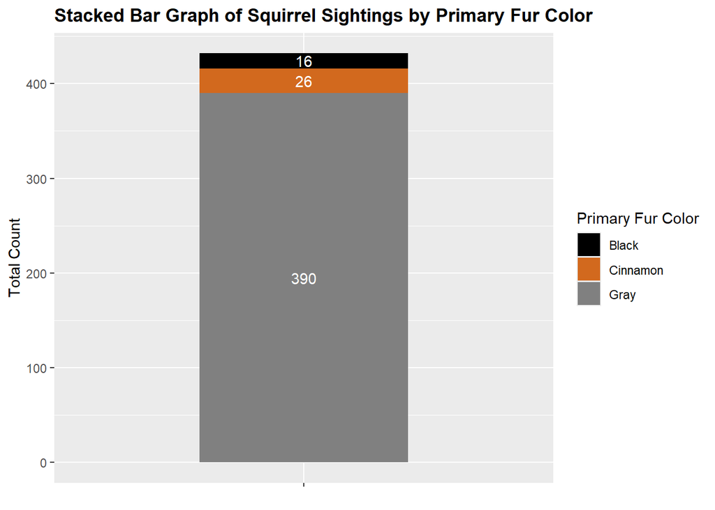

```r
nyc_squirrels %>%
    group_by(`Primary Fur Color`) %>%
    drop_na(`Primary Fur Color`) %>%
    count(sort=TRUE) %>%
    rename(`Total Count`=n) %>%
    ggplot(aes(x="",y=`Total Count`,fill=`Primary Fur Color`)) +
    geom_bar(width=.5,stat="identity",) +
    geom_text(aes(label=`Total Count`),color="white",position=position_stack(.5)) +
    scale_fill_manual(values = custom_colors) +
    theme(plot.title = element_text(face = "bold")) +
    labs(title="Stacked Bar Graph of Squirrel Sightings by Primary Fur Color",x=NULL)
```

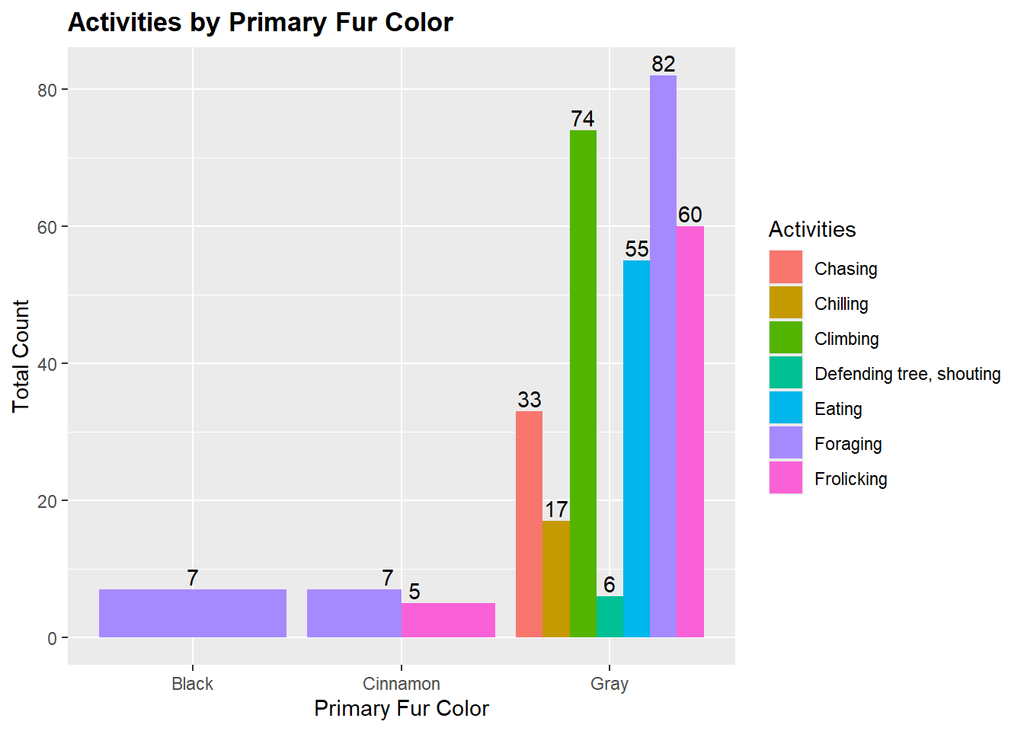

```r
nyc_squirrels %>%
    group_by(`Primary Fur Color`) %>%
    drop_na(Activities,`Primary Fur Color`) %>%
    count(Activities) %>%
    rename(`Total Count`=n) %>%
    filter(`Total Count` > 4) %>%
    ggplot(aes(x=`Primary Fur Color`,y=`Total Count`,fill=Activities, label=`Total Count`)) +
    geom_bar(stat="identity",position="dodge") +
    geom_text(position = position_dodge2(width = 0.9, preserve = "single"), angle = 0, vjust=-0.25, hjust=.5) +
    ggtitle("Activities by Primary Fur Color") +
    theme(plot.title = element_text(face = "bold"))
```

For Black squirrels, all were foraging when observed. There is more variety in activities for Cinnamon squirrels, with close to equal distribution. For Gray squirrels we can see that Foraging and Climbing were the dominant activities. Overall we can see that the pattern previously observed holds that the most popular activity for squirrels at the moment they were observed was foraging followed by climbing.

Now let’s look at how squirrels reacted to sighters.

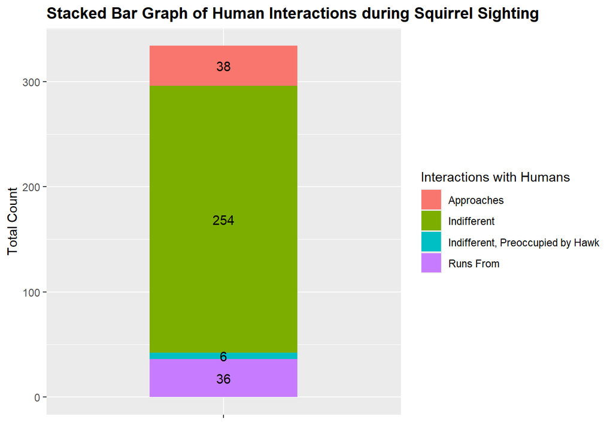

```r
nyc_squirrels %>%
    group_by(`Interactions with Humans`) %>%
    drop_na(`Interactions with Humans`) %>%
    count(sort=TRUE) %>%
    rename(`Total Count`=n) %>%
    filter(`Total Count` > 5) %>%
    ggplot(aes(x="",y=`Total Count`,fill=`Interactions with Humans`)) +
    geom_bar(width=.5,stat="identity") +
    geom_text(aes(label=`Total Count`),position=position_stack(.5)) +
    theme(plot.title = element_text(face = "bold")) +
    labs(title="Stacked Bar Graph of Human Interactions during Squirrel Sighting",x=NULL)
```

Most squirrels were indifferent to human presence followed by squirrels approaching the humans, which are the most related in terms of squirrel behavior. Now let’s look at Human interactions by primary fur color.

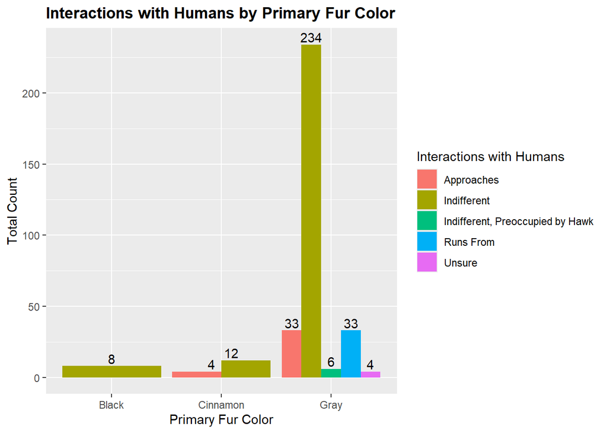

```r
nyc_squirrels %>%
    group_by(`Primary Fur Color`) %>%
    drop_na(`Interactions with Humans`,`Primary Fur Color`) %>%
    count(`Interactions with Humans`) %>%
    rename(`Total Count`=n) %>%
    filter(`Total Count` > 2) %>%
    ggplot(aes(x=`Primary Fur Color`,y=`Total Count`,fill=`Interactions with Humans`,label=`Total Count`)) +
    geom_bar(stat="identity",position="dodge") +
    geom_text(position = position_dodge2(width = 0.9, preserve = "single"), angle = 0, vjust=-0.25, hjust=.5) +
    ggtitle("Interactions with Humans by Primary Fur Color") +
    theme(plot.title = element_text(face = "bold"))
```

As we can see regardless of primary fur color squirrels were indififrent to human presence during the squirrel sighting observation process throughout all NYC Parks.

Finally, let’s look at the location of squirrels during the squirrel sightings process.

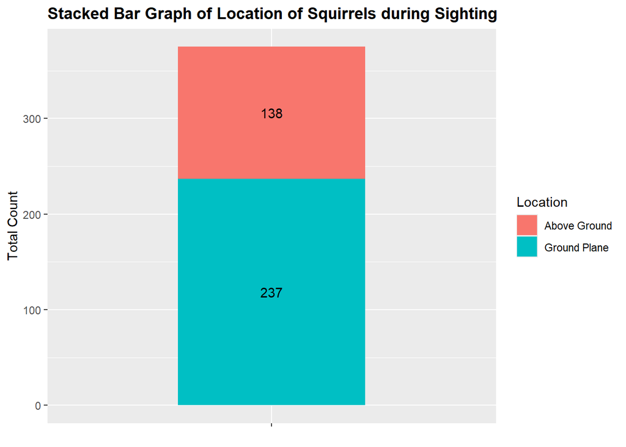

```r
nyc_squirrels %>%
    filter(Location!="Specific Location") %>%
    group_by(Location) %>%
    drop_na(Location) %>%
    count() %>%
    rename(`Total Count`=n) %>%
    ggplot(aes(x='',y=`Total Count`,fill=Location)) +
    geom_bar(width=.5,stat="identity") +
    geom_text(aes(label=`Total Count`),position=position_stack(.5)) +
    theme(plot.title = element_text(face = "bold")) +
    labs(title="Stacked Bar Graph of Location of Squirrels during Sighting",x=NULL)
```

The majority of squirrels were located on a Ground Plane during observation. Now let’s look at location by primary fur color.

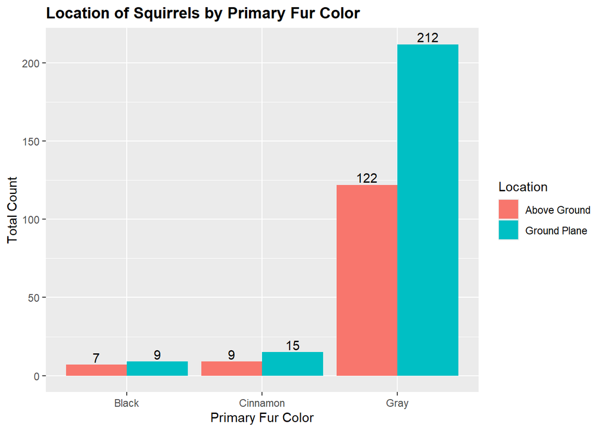

```r
nyc_squirrels %>%
    filter(Location!="Specific Location") %>%
    group_by(`Primary Fur Color`) %>%
    drop_na(Location,`Primary Fur Color`) %>%
    count(Location) %>%
    rename(`Total Count`=n) %>%
    filter(`Total Count` > 2) %>%
    ggplot(aes(x=`Primary Fur Color`,y=`Total Count`,fill=Location, label=`Total Count`)) +
    geom_bar(stat="identity",position="dodge") +
    geom_text(position = position_dodge2(width = 0.9, preserve = "single"), angle = 0, vjust=-0.25, hjust=.5) +
    ggtitle("Location of Squirrels by Primary Fur Color") +
    theme(plot.title = element_text(face = "bold"))
```

Ground Plane remains the most popular position regardless of primary fur color. Since we also have the continuous variable, Above Ground (Height in Feet), now let’s look at the distribution for height for Above Ground observations and then Above Ground Distributions by Primary Fur Color.

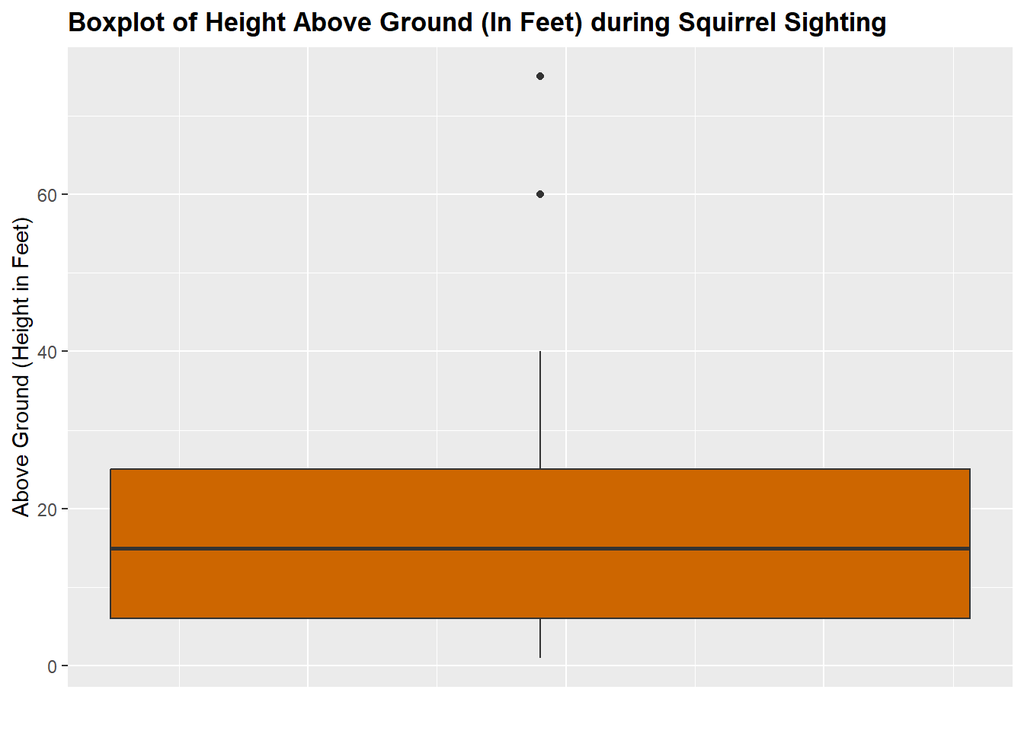

```r
nyc_squirrels %>%
    filter(!(row_number() %in% c(43,46,96,97,98,99,100,101,102,104,105,106,107,108,326,376,377))) %>%
    mutate(`Above Ground (Height in Feet)`= as.numeric(`Above Ground (Height in Feet)`)) %>%
    drop_na(`Above Ground (Height in Feet)`) %>%
    ggplot() +
    geom_boxplot(aes(x=`Above Ground (Height in Feet)`,y=`Above Ground (Height in Feet)`,group=1),fill="darkorange3") +
    ggtitle("Boxplot of Height Above Ground (In Feet) during Squirrel Sighting") +
    theme(axis.text.x=element_blank(),axis.ticks.x=element_blank(),plot.title = element_text(face = "bold")) +
    xlab("")
```

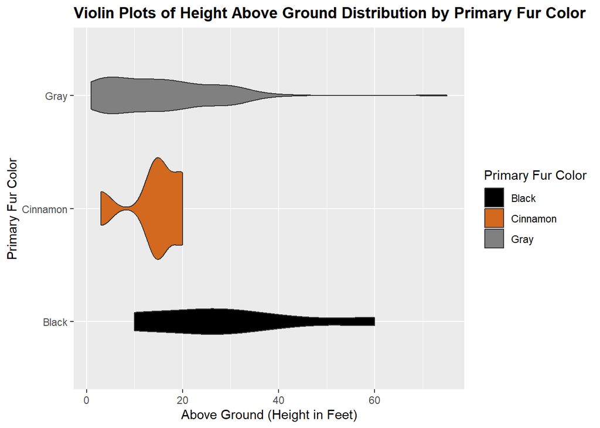

```r
nyc_squirrels %>%
    filter(!(row_number() %in% c(43,46,96,97,98,99,100,101,102,104,105,106,107,108,326,376,377))) %>%
    mutate(`Above Ground (Height in Feet)`= as.numeric(`Above Ground (Height in Feet)`)) %>%
    drop_na(`Above Ground (Height in Feet)`) %>%
    ggplot() +
    geom_violin(aes(x=`Primary Fur Color`,y=`Above Ground (Height in Feet)`,fill=`Primary Fur Color`)) +
    coord_flip() +
    ggtitle("Violin Plots of Height Above Ground Distribution by Primary Fur Color") +
    scale_fill_manual(values = custom_colors) +
    theme(plot.title=element_text(face = "bold"))
```

For gray squirrels the distribution is skewed right with a large outlier in the 60 feet range as the majority of observations are below 20 feet. For cinnamon squirrels there is an outlier near 5 feet, skewing the distribution left as most observations are near 20 feet. For black squirrels most observations are in the 18 to 35 foot range with not outliers.